# Untitled

```r
# data <- read.csv("../../.././data./01-modified-data./cleaned_data_py1.csv")
data <- read.csv("../../../data/01-modified-data/cleaned_data_py1.csv")
```

```r
head(data)
```

```
       id            title
1  926393  The Equalizer 3
2 1008042       Talk to Me
3  968051       The Nun II
4 1151534          Nowhere
5  678512 Sound of Freedom
6  937249       57 Seconds
                                                                                                                                                                                                                                      overview
1 Robert McCall finds himself at home in Southern Italy but he discovers his friends are under the control of local crime bosses. As events turn deadly, McCall knows what he has to do: become his friends' protector by taking on the mafia.
2                                           When a group of friends discover how to conjure spirits using an embalmed hand, they become hooked on the new thrill, until one of them goes too far and unleashes terrifying supernatural forces.
3                                                                                              In 1956 France, a priest is violently murdered, and Sister Irene begins to investigate. She once again comes face-to-face with a powerful evil.
4                A young pregnant woman named Mia escapes from a country at war by hiding in a maritime container aboard a cargo ship. After a violent storm, Mia gives birth to the child while lost at sea, where she must fight to survive.
5                                                                                      The story of Tim Ballard, a former US government agent, who quits his job in order to devote his life to rescuing children from global sex traffickers.
6                                                                                 When a tech blogger lands an interview with a tech guru and stops an attack on him, he finds a mysterious ring that takes him back 57 seconds into the past.
  popularity release_date vote_average vote_count
1   3197.130   2023-08-30          7.3        671
2   2629.730   2023-07-26          7.3       1235
3   2591.014   2023-09-06          7.0        849
4   2140.286   2023-09-29          7.7        523
5   1898.501   2023-07-03          8.1        789
6   1528.116   2023-09-29          5.7         54
```

```r
summary(data)
```

```
       id             title             overview           popularity
 Min.   :     11   Length:1982        Length:1982        Min.   :  35.80
 1st Qu.:  21447   Class :character   Class :character   1st Qu.:  41.96
 Median : 323082   Mode  :character   Mode  :character   Median :  51.96
 Mean   : 395937                                         Mean   :  82.55
 3rd Qu.: 705404                                         3rd Qu.:  72.83
 Max.   :1183387                                         Max.   :3197.13
 release_date        vote_average      vote_count
 Length:1982        Min.   : 0.000   Min.   :    0.0
 Class :character   1st Qu.: 6.200   1st Qu.:  192.2
 Mode  :character   Median : 6.800   Median : 2007.5
                    Mean   : 6.639   Mean   : 4038.2
                    3rd Qu.: 7.400   3rd Qu.: 5843.0
                    Max.   :10.000   Max.   :34558.0
```

```r
str(data)
```

```
'data.frame':   1982 obs. of  7 variables:
 $ id          : int  926393 1008042 968051 1151534 678512 937249 980489 575264 565770 893723 ...
 $ title       : chr  "The Equalizer 3" "Talk to Me" "The Nun II" "Nowhere" ...
 $ overview    : chr  "Robert McCall finds himself at home in Southern Italy but he discovers his friends are under the control of loc"| __truncated__ "When a group of friends discover how to conjure spirits using an embalmed hand, they become hooked on the new t"| __truncated__ "In 1956 France, a p…
 $ popularity  : num  3197 2630 2591 2140 1899 ...
 $ release_date: chr  "2023-08-30" "2023-07-26" "2023-09-06" "2023-09-29" ...
 $ vote_average: num  7.3 7.3 7 7.7 8.1 5.7 8.1 7.8 7.1 7.7 ...
 $ vote_count  : int  671 1235 849 523 789 54 965 1351 1234 34 ...
```

```r
colSums(is.na(data))
```

```
          id        title     overview   popularity release_date vote_average
           0            0            0            0            0            0
  vote_count
           0
```

```r
cor(data[, sapply(data, is.numeric)])
```

```
                     id  popularity vote_average  vote_count
id            1.0000000  0.18598981  -0.15729903 -0.46799809
popularity    0.1859898  1.00000000   0.06951356 -0.04481013
vote_average -0.1572990  0.06951356   1.00000000  0.34562377
vote_count   -0.4679981 -0.04481013   0.34562377  1.00000000
```

```r
means <- sapply(data[, sapply(data, is.numeric)], mean, na.rm=TRUE)

medians <- sapply(data[, sapply(data, is.numeric)], median, na.rm=TRUE)

std_devs <- sapply(data[, sapply(data, is.numeric)], sd, na.rm=TRUE)

variances <- sapply(data[, sapply(data, is.numeric)], var, na.rm=TRUE)

print(list(Means = means, Medians = medians, Standard_Deviations = std_devs, Variances = variances))
```

```
$Means
          id   popularity vote_average   vote_count
3.959370e+05 8.254565e+01 6.638698e+00 4.038202e+03

$Medians
          id   popularity vote_average   vote_count
  323082.000       51.957        6.800     2007.500

$Standard_Deviations
          id   popularity vote_average   vote_count
3.760296e+05 1.599089e+02 1.314091e+00 5.217476e+03

$Variances
          id   popularity vote_average   vote_count
1.413983e+11 2.557085e+04 1.726836e+00 2.722205e+07
```

```r
categorical_vars <- data[, sapply(data, is.factor)]

freq_distributions <- lapply(categorical_vars, function(x) {
  tbl <- table(x)
  prop <- prop.table(tbl)
  data.frame(Category = names(tbl), Frequency = as.numeric(tbl), Proportion = prop)
})

print(freq_distributions)
```

```
named list()
```

```r
library(ggplot2)

lapply(names(categorical_vars), function(var_name) {
  ggplot(data, aes_string(x = var_name)) +
    geom_bar() +
    labs(title = paste("Bar chart of", var_name), y = "Frequency") +
    theme_minimal()
})
```

```
list()
```

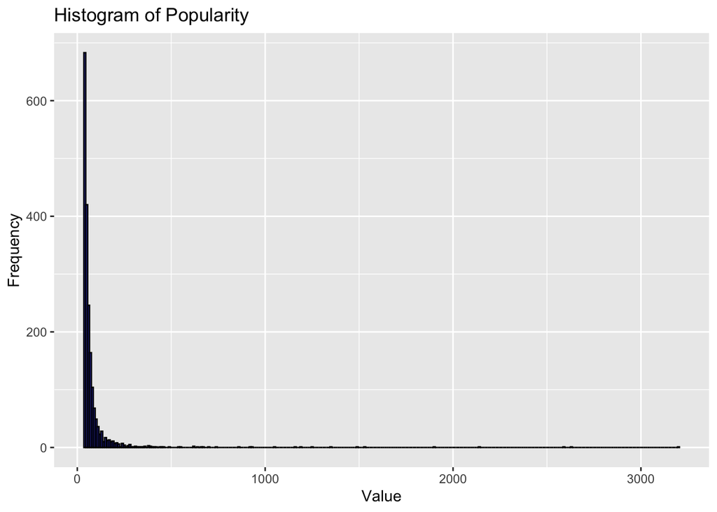

```r
# Histogram for popularity
ggplot(data, aes(x=popularity)) +
  geom_histogram(binwidth=10, fill="blue", color="black", alpha=0.7) +
  labs(title="Histogram of Popularity", x="Value", y="Frequency")
```

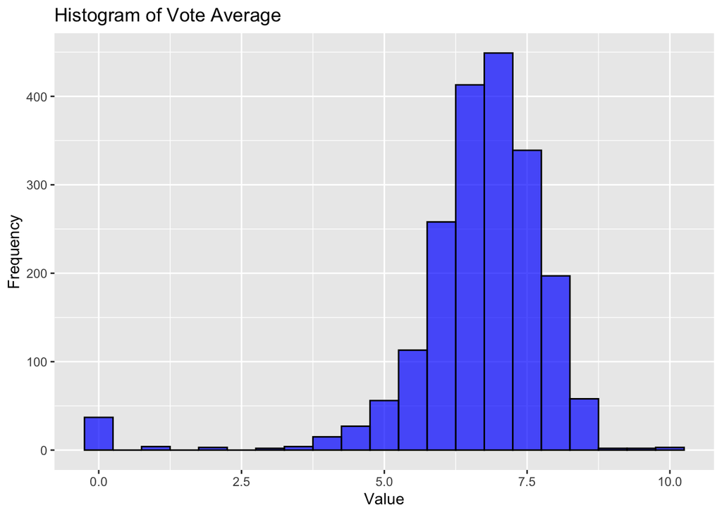

```r
# Histogram for vote_average
ggplot(data, aes(x=vote_average)) +
  geom_histogram(binwidth=0.5, fill="blue", color="black", alpha=0.7) +
  labs(title="Histogram of Vote Average", x="Value", y="Frequency")
```

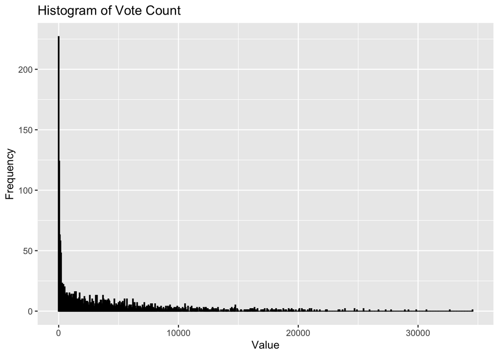

```r
# Histogram for vote_count
ggplot(data, aes(x=vote_count)) +
  geom_histogram(binwidth=50, fill="blue", color="black", alpha=0.7) +
  labs(title="Histogram of Vote Count", x="Value", y="Frequency")
```

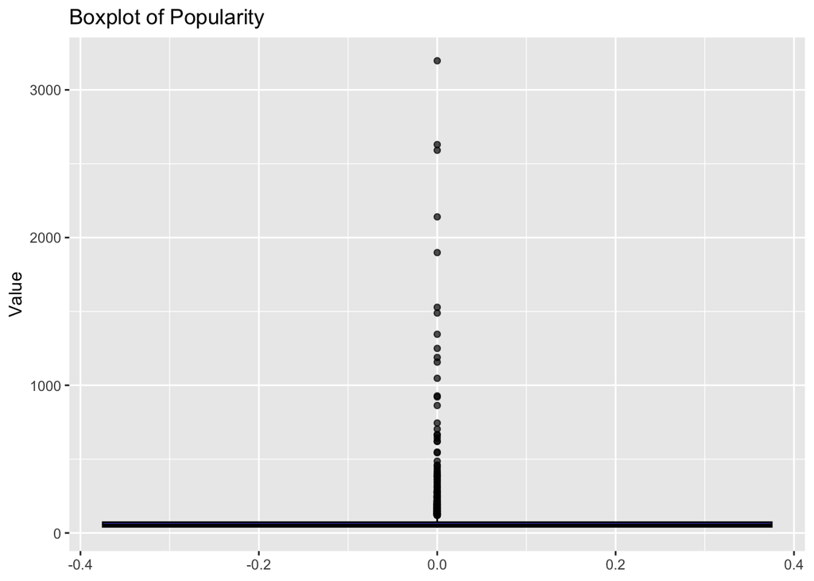

```r
# Boxplot for popularity
ggplot(data, aes(y=popularity)) +
  geom_boxplot(fill="blue", color="black", alpha=0.7) +
  labs(title="Boxplot of Popularity", y="Value")
```

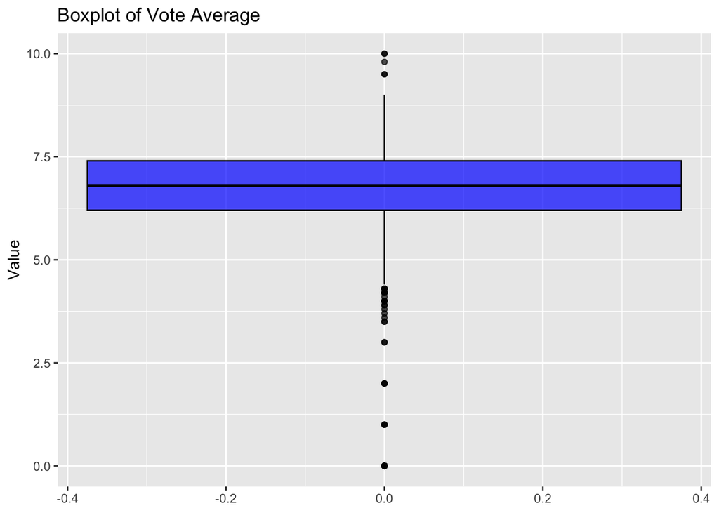

```r
# Boxplot for vote_average
ggplot(data, aes(y=vote_average)) +
  geom_boxplot(fill="blue", color="black", alpha=0.7) +
  labs(title="Boxplot of Vote Average", y="Value")
```

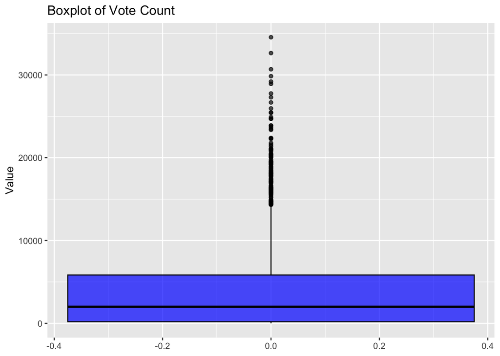

```r
# Boxplot for vote_count
ggplot(data, aes(y=vote_count)) +
  geom_boxplot(fill="blue", color="black", alpha=0.7) +
  labs(title="Boxplot of Vote Count", y="Value")
```

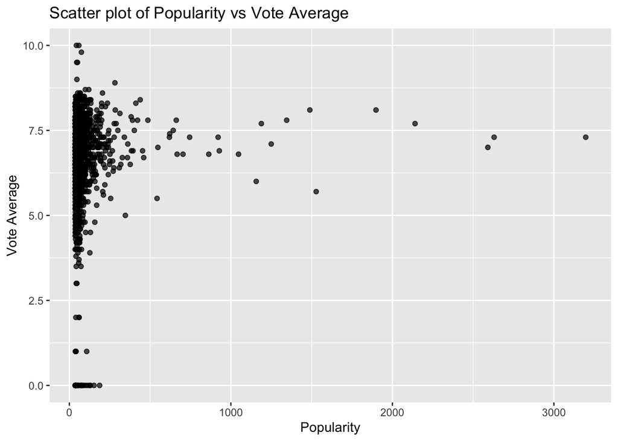

```r
# Scatter plot of popularity vs vote_average
ggplot(data, aes(x=popularity, y=vote_average)) +
  geom_point(alpha=0.7) +
  labs(title="Scatter plot of Popularity vs Vote Average", x="Popularity", y="Vote Average")
```

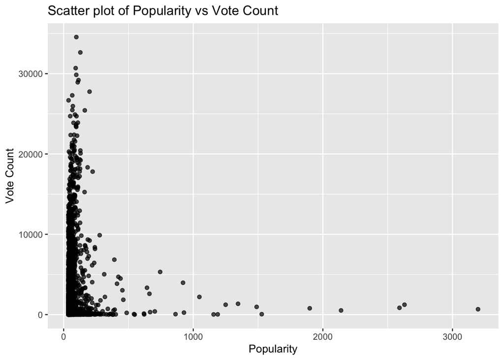

```r
# Scatter plot of popularity vs vote_count
ggplot(data, aes(x=popularity, y=vote_count)) +
  geom_point(alpha=0.7) +
  labs(title="Scatter plot of Popularity vs Vote Count", x="Popularity", y="Vote Count")
```

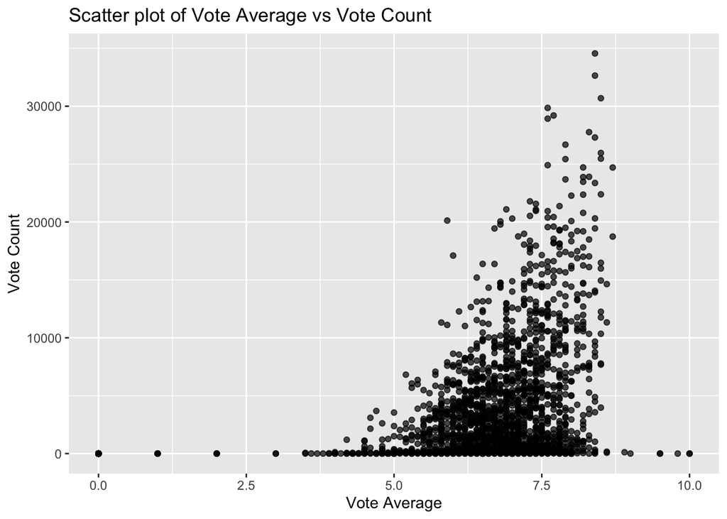

```r
# Scatter plot of vote_average vs vote_count
ggplot(data, aes(x=vote_average, y=vote_count)) +
  geom_point(alpha=0.7) +
  labs(title="Scatter plot of Vote Average vs Vote Count", x="Vote Average", y="Vote Count")
```

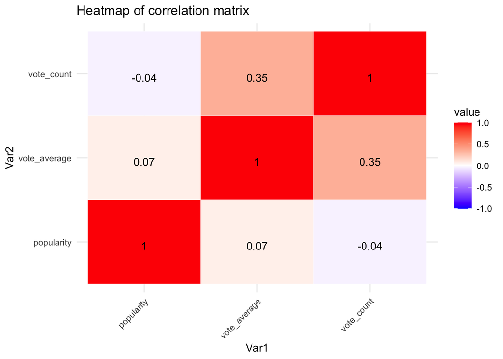

```r
cor_matrix <- cor(data[,c("popularity", "vote_average", "vote_count")], use="complete.obs")
library(reshape2)
cor_melted <- melt(cor_matrix)

ggplot(cor_melted, aes(x=Var1, y=Var2)) +
  geom_tile(aes(fill=value), color="white") +
  scale_fill_gradient2(low="blue", high="red", mid="white", midpoint=0, limit=c(-1,1)) +
  geom_text(aes(label=round(value, 2)), vjust=1) +
  labs(title="Heatmap of correlation matrix") +
  theme_minimal() +
  theme(axis.text.x=element_text(angle=45, vjust=1, hjust=1))
```

```r
cor_matrix <- cor(data[,c("popularity", "vote_average", "vote_count")], use="complete.obs")
print(cor_matrix)
```

```
              popularity vote_average  vote_count
popularity    1.00000000   0.06951356 -0.04481013
vote_average  0.06951356   1.00000000  0.34562377
vote_count   -0.04481013   0.34562377  1.00000000
```

Hypothesis Generation.

1. Movie popularity is positively related to the number of votes cast: It is hypothesized that popular movies may receive more votes because more viewers may have seen and rated them.

2. Average vote score is positively related to the number of votes: High quality movies may attract more viewers and thus get more votes. However, it is also possible that even if a movie receives many votes, its average score is not necessarily high.

3. Recently released movies may have higher popularity: Recently released movies may have high popularity because they are likely to be hot topics of interest to the audience.

4. The length of the synopsis is not significantly related to popularity: The synopsis of a movie may not have a direct effect on the popularity of the movie, however, if the synopsis is able to attract the audience, then it may have an indirect effect on the popularity of the movie.

Research Question.

1. which genre of movie is the most popular? By looking at other variables in the dataset, such as movie genre or director, we can further explore which genre of movie is most popular with audiences.

2. does popularity change over time? Are there certain years or seasons where movies released during those periods are more popular?

3. what are the common characteristics of highly rated movies? Is it the director, the actors, the genre or other factors?

4. is the length of a movie’s synopsis related to its popularity? Do longer synopses attract more viewers than shorter ones?

```r
data$rating_group <- cut(data$vote_average, breaks = c(0, 5, 7, 10), labels = c("Low", "Medium", "High"))
```

```r
data$release_year <- as.numeric(format(as.Date(data$release_date, format="%Y-%m-%d"), "%Y"))
data$release_month <- as.numeric(format(as.Date(data$release_date, format="%Y-%m-%d"), "%m"))
```

```r
data$popularity_group <- cut(data$popularity, breaks = quantile(data$popularity, c(0, .33, .66, 1)), labels = c("Low", "Medium", "High"))
```

```r
data$vote_count_group <- cut(data$vote_count, breaks = quantile(data$vote_count, c(0, .33, .66, 1)), labels = c("Low", "Medium", "High"))
```

```r
library(dplyr)
data %>%
  group_by(rating_group) %>%
  summarise(
    avg_popularity = mean(popularity, na.rm = TRUE),
    median_vote_count = median(vote_count, na.rm = TRUE),
    count = n()
  )
```

```
# A tibble: 4 × 4
  rating_group avg_popularity median_vote_count count
  <fct>                 <dbl>             <dbl> <int>
1 Low                    58.0               12     94
2 Medium                 73.5             1700   1085
3 High                   99.2             4188.   766
4 <NA>                   65.8                0     37
```

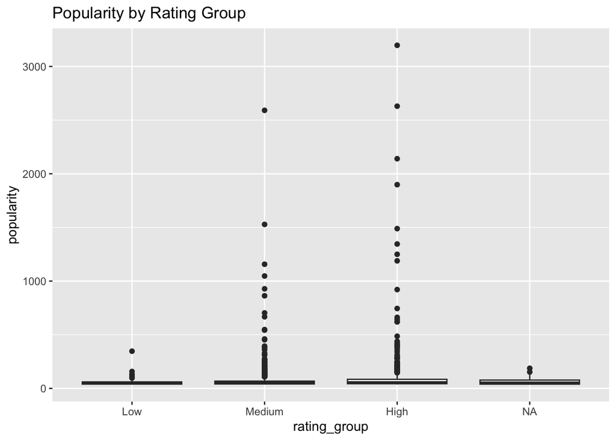

```r
library(ggplot2)

ggplot(data, aes(x = rating_group, y = popularity)) +
  geom_boxplot() +
  ggtitle("Popularity by Rating Group")
```

```r
library(stats)
result <- aov(popularity ~ rating_group, data = data)
summary(result)
```

```
               Df   Sum Sq Mean Sq F value   Pr(>F)
rating_group    2   359574  179787    6.95 0.000983 ***
Residuals    1942 50237711   25869
---
Signif. codes:  0 '***' 0.001 '**' 0.01 '*' 0.05 '.' 0.1 ' ' 1
37 observations deleted due to missingness
```

```r
table(data$rating_group, data$popularity_group)
```

```
         Low Medium High
  Low     38     35   21
  Medium 393    367  324
  High   206    245  315
```

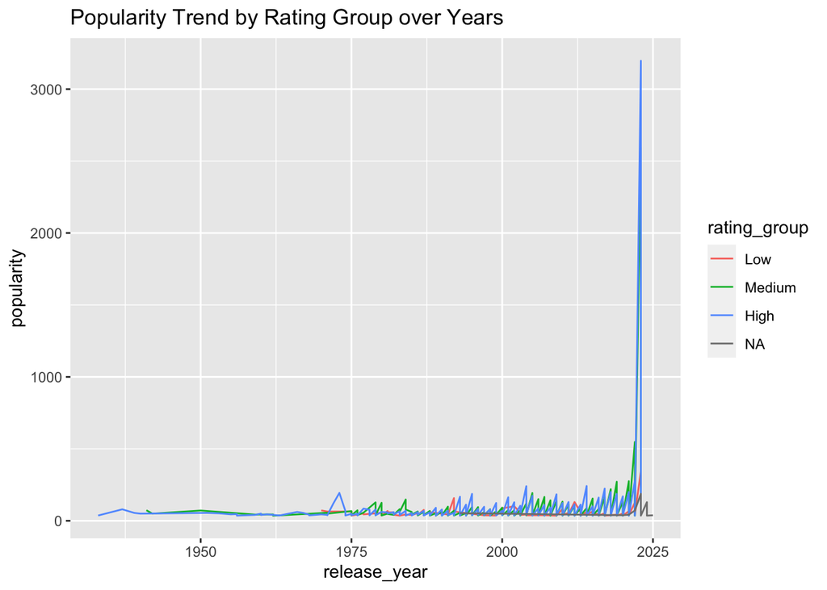

```r
ggplot(data, aes(x = release_year, y = popularity, color = rating_group)) +
  geom_line() +
  ggtitle("Popularity Trend by Rating Group over Years")
```

```r
Q1 <- quantile(data$popularity, 0.25)
Q3 <- quantile(data$popularity, 0.75)
IQR <- Q3 - Q1

lower_bound <- Q1 - 1.5 * IQR
upper_bound <- Q3 + 1.5 * IQR

outliers_popularity <- data$popularity[data$popularity < lower_bound | data$popularity > upper_bound]
outliers_popularity
```

[output not shown]

```r
Q1_vote_avg <- quantile(data$vote_average, 0.25)
Q3_vote_avg <- quantile(data$vote_average, 0.75)
IQR_vote_avg <- Q3_vote_avg - Q1_vote_avg

lower_bound_vote_avg <- Q1_vote_avg - 1.5 * IQR_vote_avg
upper_bound_vote_avg <- Q3_vote_avg + 1.5 * IQR_vote_avg

outliers_vote_avg <- data$vote_average[data$vote_average < lower_bound_vote_avg | data$vote_average > upper_bound_vote_avg]
outliers_vote_avg
```

```
 [1]  0.0  0.0  0.0  0.0  3.9  0.0  1.0  0.0  0.0  0.0  0.0  0.0  0.0  4.0  9.8
[16]  3.5  0.0  0.0  0.0  4.3  4.3  4.2  4.0  2.0  4.2  3.7  2.0 10.0  3.6  0.0
[31]  4.3  0.0  0.0  0.0  3.9  0.0  9.5  4.0  4.3  0.0  4.1  0.0  3.0  4.2  9.5
[46]  0.0  4.0  0.0  4.2  4.2 10.0  0.0  0.0  3.5  3.0  0.0  4.0  1.0  3.8  2.0
[61]  0.0  0.0  0.0  1.0  0.0  0.0  0.0  4.3  0.0  1.0  0.0  0.0  0.0  0.0  4.0
```

```r
Q1_vote_count <- quantile(data$vote_count, 0.25)
Q3_vote_count <- quantile(data$vote_count, 0.75)
IQR_vote_count <- Q3_vote_count - Q1_vote_count

lower_bound_vote_count <- Q1_vote_count - 1.5 * IQR_vote_count
upper_bound_vote_count <- Q3_vote_count + 1.5 * IQR_vote_count

outliers_vote_count <- data$vote_count[data$vote_count < lower_bound_vote_count | data$vote_count > upper_bound_vote_count]
outliers_vote_count
```

[output not shown]

**Answer for 8**

1. Overview of methods.

In performing Exploratory Data Analysis (EDA), we use a range of techniques and methods to gain insight into the data set. Initial steps include data understanding, descriptive statistics, data visualization, correlation analysis, hypothesis generation, data grouping and segmentation, and outlier detection.

2. Key Findings.

Data Visualization: Through histograms, box plots, and scatter plots, we conducted in-depth explorations of the distributions and relationships between features in the dataset. For example, the distribution of popularity shows that most of the movies in the dataset are moderately popular, but a few are very popular.

Outlier Detection: Through the IQR method, we identified outliers in vote_average and several other variables. These outliers may indicate data quality issues or interesting anomalies in the dataset.

4 Conclusions and insights.

Summarizing the above analysis, we can draw the following conclusions and insights:

There are some outliers in the dataset, which may be due to data entry errors, or a true reflection of some specific situations.

By grouping and segmenting the data, we can gain more insight into trends and patterns within specific subgroups.

For further data analysis or modeling, we recommend more in-depth feature engineering, as well as considering the use of more advanced statistical models or machine learning techniques. In addition, based on our findings, producers or distributors could consider different promotional strategies to more effectively increase the visibility and popularity of their movies.

**Answer for 9**

Tools and Software.

During Exploratory Data Analysis (EDA), choosing the right tools and software is critical as they help us to effectively process data, create visualizations, and draw meaningful conclusions. Below are the main tools and software we used for this project:

R: This EDA was mainly analyzed using R. R is an open source programming language and software environment developed for statistical computing and graphical design. Thanks to its powerful statistical functions and plotting libraries, R is widely popular in the field of data analysis.

ggplot2: This is an R-based data visualization package that provides an efficient way to create complex statistical graphs. In this project, we used ggplot2 to create histograms, box plots, scatter plots, and other graphs to explore the characteristics of the dataset.

The choice of R and its associated libraries as the primary EDA tool was based on the following considerations:

Flexibility: R offers a wide range of statistical and data analysis capabilities to meet a variety of complex analysis needs.

Community Support: R has a very active community where users can find a large number of online tutorials, guides and answers to questions.

Extensibility: R has thousands of available packages that can be used for a variety of statistical, machine learning, and data visualization tasks.